# FML-4

RohitV

2023-10-27

```r
##Load the librabries

library(factoextra)
```

```r
library(ggplot2)
library(tidyverse)
library(ISLR)
library(NbClust)
library(cluster)
```

```r
## Import the data from csv file.

Pharmaceutical <- read.csv("/Users/machd/Downloads/Pharmaceuticals.csv")
view(Pharmaceutical)
```

## a. Use only the numerical variables (1 to 9) to cluster the 21 firms. Justify the various choices made in conducting the cluster analysis, such as weights for different variables, the specific clustering algorithm(s) used, the number of clusters formed, and so on.

```r
##Create a new data frame 'A' by removing rows with missing values from 'Pharmaceuticals'
R <- na.omit(Pharmaceutical)
summary(R)
```

```
##     Symbol              Name             Market_Cap          Beta
##  Length:21          Length:21          Min.   :  0.41   Min.   :0.1800
##  Class :character   Class :character   1st Qu.:  6.30   1st Qu.:0.3500
##  Mode  :character   Mode  :character   Median : 48.19   Median :0.4600
##                                        Mean   : 57.65   Mean   :0.5257
##                                        3rd Qu.: 73.84   3rd Qu.:0.6500
##                                        Max.   :199.47   Max.   :1.1100
##     PE_Ratio          ROE            ROA        Asset_Turnover    Leverage
##  Min.   : 3.60   Min.   : 3.9   Min.   : 1.40   Min.   :0.3    Min.   :0.0000
##  1st Qu.:18.90   1st Qu.:14.9   1st Qu.: 5.70   1st Qu.:0.6    1st Qu.:0.1600
##  Median :21.50   Median :22.6   Median :11.20   Median :0.6    Median :0.3400
##  Mean   :25.46   Mean   :25.8   Mean   :10.51   Mean   :0.7    Mean   :0.5857
##  3rd Qu.:27.90   3rd Qu.:31.0   3rd Qu.:15.00   3rd Qu.:0.9    3rd Qu.:0.6000
##  Max.   :82.50   Max.   :62.9   Max.   :20.30   Max.   :1.1    Max.   :3.5100
##    Rev_Growth    Net_Profit_Margin Median_Recommendation   Location
##  Min.   :-3.17   Min.   : 2.6      Length:21             Length:21
##  1st Qu.: 6.38   1st Qu.:11.2      Class :character      Class :character
##  Median : 9.37   Median :16.1      Mode  :character      Mode  :character
##  Mean   :13.37   Mean   :15.7
##  3rd Qu.:21.87   3rd Qu.:21.1
##  Max.   :34.21   Max.   :25.5
##    Exchange
##  Length:21
##  Class :character
##  Mode  :character
##
##
##
```

```r
#Set row names of the data frame 'A' to the values in its first column
row.names(R) <- R[,1]
#Create a new data frame 'Pharma' containing columns 3 to 11 from 'A'
Pharmacy <- R[,3:11]
#Display the rows of the 'Pharma' data frame
head(Pharmacy)
```

```
##     Market_Cap Beta PE_Ratio  ROE  ROA Asset_Turnover Leverage Rev_Growth
## ABT      68.44 0.32     24.7 26.4 11.8            0.7     0.42       7.54
## AGN       7.58 0.41     82.5 12.9  5.5            0.9     0.60       9.16
## AHM       6.30 0.46     20.7 14.9  7.8            0.9     0.27       7.05
## AZN      67.63 0.52     21.5 27.4 15.4            0.9     0.00      15.00
## AVE      47.16 0.32     20.1 21.8  7.5            0.6     0.34      26.81
## BAY      16.90 1.11     27.9  3.9  1.4            0.6     0.00      -3.17
##     Net_Profit_Margin
## ABT              16.1
## AGN               5.5
## AHM              11.2
## AZN              18.0
## AVE              12.9
## BAY               2.6
```

```r
# Scale the data in the 'Pharma' data frame to standardize variables
Pharmacist <- scale (Pharmacy)

head(Pharmacist)
```

```
##     Market_Cap        Beta    PE_Ratio         ROE        ROA Asset_Turnover
## ABT  0.1840960 -0.80125356 -0.04671323  0.04009035  0.2416121      0.0000000
## AGN -0.8544181 -0.45070513  3.49706911 -0.85483986 -0.9422871      0.9225312
## AHM -0.8762600 -0.25595600 -0.29195768 -0.72225761 -0.5100700      0.9225312
## AZN  0.1702742 -0.02225704 -0.24290879  0.10638147  0.9181259      0.9225312
## AVE -0.1790256 -0.80125356 -0.32874435 -0.26484883 -0.5664461     -0.4612656
## BAY -0.6953818  2.27578267  0.14948233 -1.45146000 -1.7127612     -0.4612656
##       Leverage Rev_Growth Net_Profit_Margin
## ABT -0.2120979 -0.5277675        0.06168225
## AGN  0.0182843 -0.3811391       -1.55366706
## AHM -0.4040831 -0.5721181       -0.68503583
## AZN -0.7496565  0.1474473        0.35122600
## AVE -0.3144900  1.2163867       -0.42597037
## BAY -0.7496565 -1.4971443       -1.99560225
```

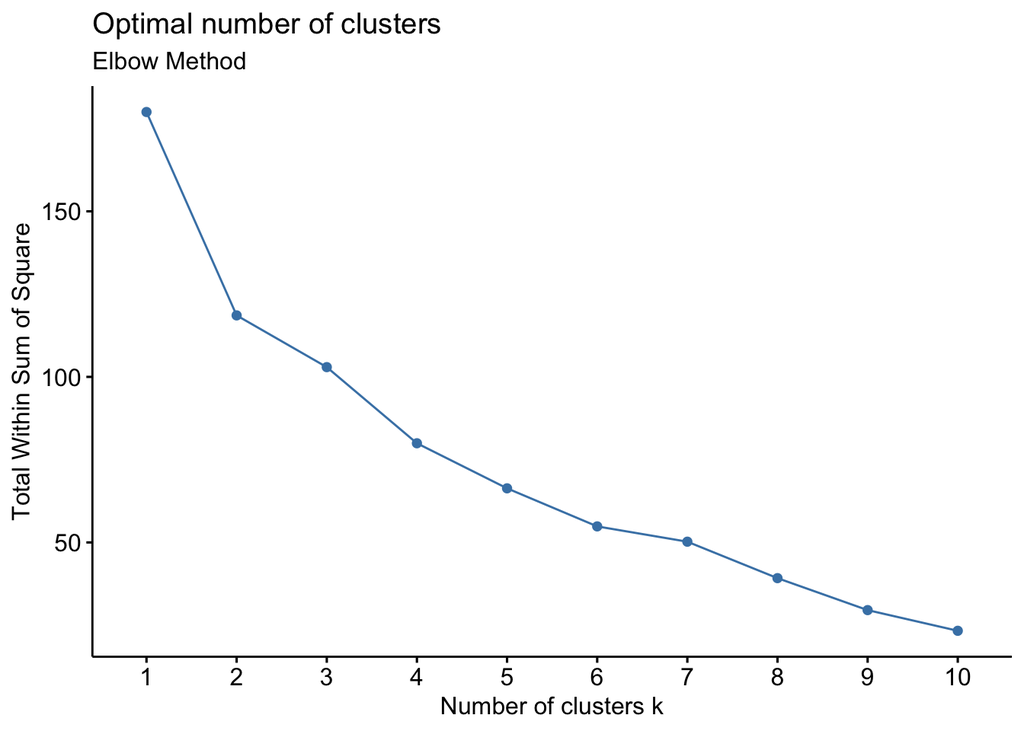

```r
fviz_nbclust(Pharmacist, kmeans, method = "wss") + labs(subtitle = "Elbow Method")
```

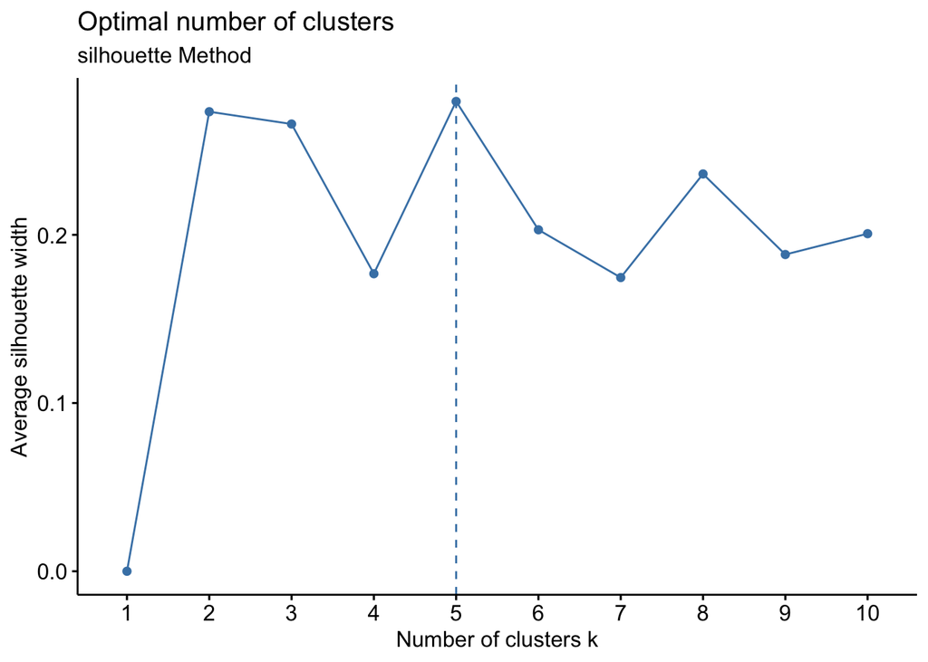

```r
fviz_nbclust(Pharmacist, kmeans, method = "silhouette") + labs(subtitle = "silhouette Method")
```

```r
set.seed(64060)
k5 <- kmeans(Pharmacy, centers = 5, nstart = 25)
k5$centers
```

```
##   Market_Cap      Beta PE_Ratio   ROE       ROA Asset_Turnover Leverage
## 1   4.492857 0.7342857 20.72857 14.40  5.371429      0.5428571 1.061429
## 2  60.917500 0.3962500 20.21250 29.60 12.650000      0.7000000 0.380000
## 3 127.335000 0.4050000 18.45000 51.75 17.650000      1.0500000 0.310000
## 4 186.700000 0.5550000 26.00000 37.10 17.750000      0.8500000 0.130000
## 5  31.910000 0.4050000 69.50000 13.20  5.600000      0.7500000 0.475000
##   Rev_Growth Net_Profit_Margin
## 1   16.85857          11.71429
## 2    8.06125          19.56250
## 3   19.61000          17.60000
## 4   17.45500          21.55000
## 5   12.08000           6.40000
```

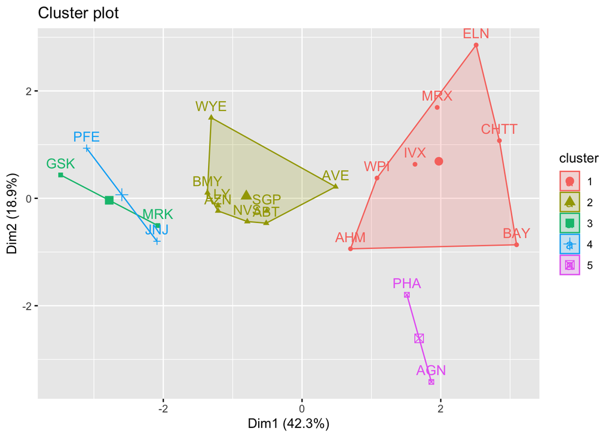

```r
fviz_cluster(k5, data = Pharmacist)
```

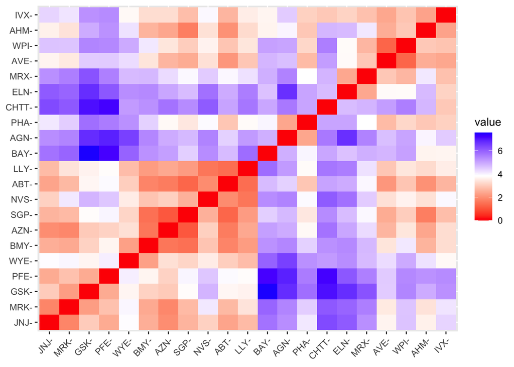

```r
# Calculate the Euclidean distance matrix between observations in the 'Pharma1' dataset
distance <- dist(Pharmacist, method = "euclidean")
fviz_dist(distance)
```

```r
# Set the CRAN mirror to a specific location
options(repos = c(CRAN = "https://cran.rstudio.com/"))
```

```r
fit <-kmeans(Pharmacist, 5)
aggregate(Pharmacist, by = list(fit$cluster), FUN=mean)
```

```
##   Group.1  Market_Cap       Beta   PE_Ratio        ROE        ROA
## 1       1  1.69558112 -0.1780563 -0.1984582  1.2349879  1.3503431
## 2       2 -0.66114002 -0.7233539 -0.3512251 -0.6736441 -0.5915022
## 3       3 -0.96247577  1.1949250 -0.3639982 -0.5200697 -0.9610792
## 4       4 -0.52462814  0.4451409  1.8498439 -1.0404550 -1.1865838
## 5       5  0.08926902 -0.4618336 -0.3208615  0.3260892  0.5396003
##   Asset_Turnover   Leverage Rev_Growth Net_Profit_Margin
## 1   1.153164e+00 -0.4680782  0.4671788         0.5912425
## 2  -1.537552e-01 -0.4040831  0.6917224        -0.4005718
## 3  -1.153164e+00  1.4773718  0.7120120        -0.3688236
## 4   1.480297e-16 -0.3443544 -0.5769454        -1.6095439
## 5   6.589509e-02 -0.2559803 -0.7230135         0.7343816
```

```r
Pharmacist1 <- data.frame(Pharmacist, fit$cluster)
Pharmacist1
```

```
##      Market_Cap        Beta    PE_Ratio         ROE        ROA Asset_Turnover
## ABT   0.1840960 -0.80125356 -0.04671323  0.04009035  0.2416121      0.0000000
## AGN  -0.8544181 -0.45070513  3.49706911 -0.85483986 -0.9422871      0.9225312
## AHM  -0.8762600 -0.25595600 -0.29195768 -0.72225761 -0.5100700      0.9225312
## AZN   0.1702742 -0.02225704 -0.24290879  0.10638147  0.9181259      0.9225312
## AVE  -0.1790256 -0.80125356 -0.32874435 -0.26484883 -0.5664461     -0.4612656
## BAY  -0.6953818  2.27578267  0.14948233 -1.45146000 -1.7127612     -0.4612656
## BMY  -0.1078688 -0.10015669 -0.70887325  0.59693581  0.8617498      0.9225312
## CHTT -0.9767669  1.26308721  0.03299122 -0.11237924 -1.1677918     -0.4612656
## ELN  -0.9704532  2.15893320 -1.34037772 -0.70899938 -1.0174553     -1.8450624
## LLY   0.2762415 -1.34655112  0.14948233  0.34502953  0.5610770     -0.4612656
## GSK   1.0999201 -0.68440408 -0.45749769  2.45971647  1.8389364      1.3837968
## IVX  -0.9393967  0.48409069 -0.34100657 -0.29136529 -0.6979905     -0.4612656
## JNJ   1.9841758 -0.25595600  0.18013789  0.18593083  1.0872544      0.9225312
## MRX  -0.9632863  0.87358895  0.19240011 -0.96753478 -0.9610792     -1.8450624
## MRK   1.2782387 -0.25595600 -0.40231769  0.98142435  0.8429577      1.8450624
## NVS   0.6654710 -1.30760129 -0.23677768 -0.52338423  0.1288598     -0.9225312
## PFE   2.4199899  0.48409069 -0.11415545  1.31287998  1.6322239      0.4612656
## PHA  -0.0240846 -0.48965495  1.90298017 -0.81506519 -0.9047030     -0.4612656
## SGP  -0.4018812 -0.06120687 -0.40231769 -0.21181593  0.5234929      0.4612656
## WPI  -0.9281345 -1.11285216 -0.43297324 -1.03382590 -0.6979905     -0.9225312
## WYE  -0.1614497  0.40619104 -0.75792214  1.92938746  0.5422849     -0.4612656
##         Leverage  Rev_Growth Net_Profit_Margin fit.cluster
## ABT  -0.21209793 -0.52776752        0.06168225           5
## AGN   0.01828430 -0.38113909       -1.55366706           4
## AHM  -0.40408312 -0.57211809       -0.68503583           2
## AZN  -0.74965647  0.14744734        0.35122600           5
## AVE  -0.31449003  1.21638667       -0.42597037           2
## BAY  -0.74965647 -1.49714434       -1.99560225           4
## BMY  -0.02011273 -0.96584257        0.74744375           5
## CHTT  3.74279705 -0.63276071       -1.24888417           3
## ELN   0.61983791  1.88617085       -0.36501379           3
## LLY  -0.07130879 -0.64814764        1.17413980           5
## GSK  -0.31449003  0.76926048        0.82363947           1
## IVX   1.10620040  0.05603085       -0.71551412           3
## JNJ  -0.62166634 -0.36213170        0.33598685           1
## MRX   0.44065173  1.53860717        0.85411776           3
## MRK  -0.39128411  0.36014907       -0.24310064           1
## NVS  -0.67286239 -1.45369888        1.02174835           5
## PFE  -0.54487226  1.10143723        1.44844440           1
## PHA  -0.30169102  0.14744734       -1.27936246           4
## SGP  -0.74965647 -0.43544591        0.29026942           5
## WPI  -0.49367621  1.43089863       -0.09070919           2
## WYE   0.68383297 -1.17763919        1.49416183           5
```

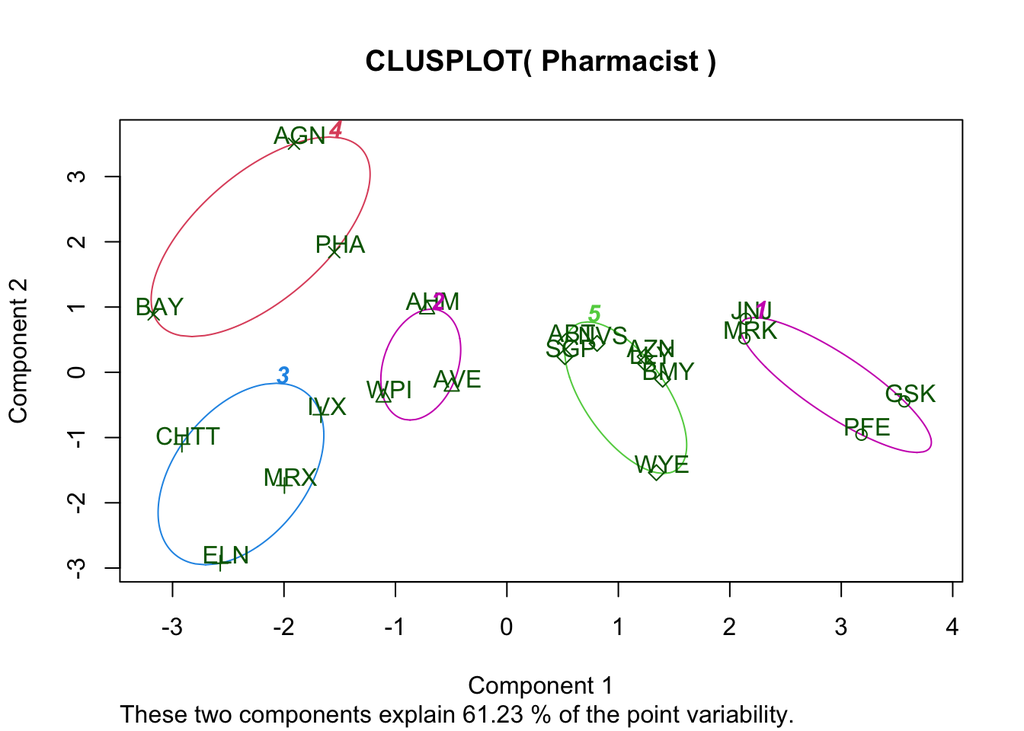

```r
clusplot(Pharmacist, fit$cluster, color = TRUE, shade = FALSE, labels = 2, lines = 0)
```

## b. Interpret the clusters with respect to the numerical variables used in forming the clusters.

##JNJ, MRK, PFE, and GSK are among the companies that make up Cluster 1; these businesses have the biggest market capitalizations and rely on financing to run their businesses effectively. (less leverage than 0.47).

#They have the quickest revenue growth in Cluster 3, are the least capitalized company on the market, and are unable to even raise capital to sustain their operations. (ELN, LVX, CHTT, MRX). The high beta values of these business stocks contribute to their impressive returns.

#Cluster 4: RHA, BAY, and AGN They have the lowest earnings due to their highest expense to earnings ratio. It is also unlikely that investing in these companies will result in the highest returns because their Return on Equity is less than 1.

## c. Is there a pattern in the clusters with respect to the numerical variables (10 to 12)? (those not used in forming the clusters)

#The stocks in Cluster-1 are not particularly strong or have shown notable returns in the recent past. Instead, they have a mediocre personality.

#Cluster-2’s businesses are dispersed equally throughout the globe. Their concepts have been widely accepted by the media, despite their strong technical foundation.

#Cluster 3: Because of the stability of their finances, they are only moderately advised despite having a high leverage ratio.

#Parts within Group 4 According to the media, they ought to be kept around because they might one day become extremely valuable assets.

#Cluster No. 5: Businesses with a high net profit margin are encouraged to remain in the cluster for an extended period of time.

## d. Provide an appropriate name for each cluster using any or all of the variables in the dataset.

#Cluster 1: A practical approach (given that these are respectable stocks).

#A group of gold miners, Cluster-2 has a low beta, but the market is extremely bullish on them..

#The recurrent cluster is cluster 5. It is strongly advised to include the stocks in the portfolio because a sizable net profit margin suggests that the company is operating profitably.